# Intro to R Part 1:

Getting Started

[figure not shown]

Andy Lyons  
October 11, 2022

https://ucanr-igis.github.io/IntroR_Oct22/

[figure not shown]

# About Me…

[figure not shown]

# About You

## Number of registrants: 89

Familiarity with R

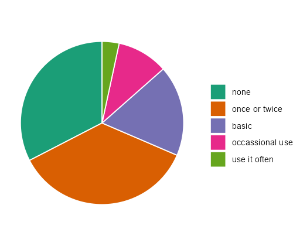

Email domain

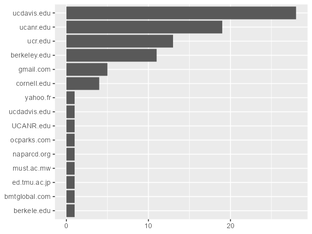

Location

[interactive chart not shown]

# Goal

Move in the direction of becoming functional with R!!

## Learning Strategy

1) Understand foundational terms and concepts

2) Hands-on practice

3) Discover RStudio’s bells and whistles

4) Learn how to get help

## Today’s Focus

[figure not shown]

## Learning Tips

1) Watch now, practice later

2) Review what we cover within 24 hours

# Workshop Series

| Date | Session |
| --- | --- |
| Oct. 11, 2022 3:30p - 5:00p | Part 1. Getting Started |
| Oct 12, 2022 3:30p - 5:00p | Part 2. Packages, Piping, and Importing Data |
| Oct 14, 2022 10:30a - 12:00p | Part III. Data Wrangling |

See also [**Getting Started with R**](https://igis.ucanr.edu/Training/Learn-R/) resources.

# R and RStudio

**Why is R So Popular?**

1. It’s free!
2. Huge user community (especially academics)
3. Thousands of add-ons (packages) that extend its capabilities
4. Particularly strong in plotting and reporting
5. Once you get over the initial hump, can work very efficiently
6. Makes it easy to get your code “out there”
7. Solid overall programming language

[figure not shown]

- a programming language to write scripts
- software (“environment”) that interprets scripts written in R
- inspired by ‘S’ (1976), first beta version ~2000
- [*lots*](https://rdrr.io/) of user-contributed packages:
  - *CRAN*: >22,000
  - *Bioconductor*: >2,000
  - *R-Forge*: >2,000
  - *GitHub*: >85,400

[figure not shown]

- a very popular tool (IDE) to work with both R software and R scripts
- Version 1.0 came out in late 2016
- RStudio needs R to run, but you can use R without RStudio
- [RStudio Cloud](https://rstudio.cloud/) - run RStudio through a browser

[figure not shown]

- online version of RStudio
- requires an account (free account gets you 15 hrs / month)
- 98% same as RStudio Desktop
- have to upload your data to the cloud
- everything gets saved between sessions
- workspaces and projects can be shared with collaborators

# Exercise 1: RStudio Exploration and Basic Commands

*Exercise 1 Topics*

1. Using R like a fancy calculator
2. Order of operations
3. Comparison operators
4. Saving the results of expressions to variable
5. Rules for naming variables

RStudio Cloud project for this workshop:

https://rstudio.cloud/content/4701501

After it opens:

[figure not shown]

# Break!

[figure not shown]

# Exercise Review

Key vocabulary terms are in *italic*.

- When you enter an *expression* at the *console*, R will *evaluate* the expression, and *print the results* at the console.
- If you enter an *incomplete expression*, R will prompt you to finish the job by showing a ‘+’ symbol in the console
- You can *save* the results of an expression to an *object* (variable) using an *assignment operator*  
  **`=`**  
  **`<-`**
- R objects can be named almost anything (but *no spaces* or *hyphens* please)
- R is *case sensitive* about **everything**
- Once defined, R objects can be used in *subsequent expressions*
- R objects can be *updated* (assigned a new value)
- R objects are only saved in *memory*, and will disappear when you close RStudio
- *Comparison operators* return TRUE or FALSE (aka Logical values)
- `> >= < <= ==`
- R has a few built-in *constants*, which are like objects but you don’t have to define them

# Naming Objects

The rules for naming objects are pretty flexible. You can use numbers, letters, and most special characters.

A few rules to take note of:

- Can’t start with a number: 3pieces
- Hyphens and spaces not allowed: first name, last-name
- Don’t use the name of a built-in function, constant, or keyword: c, pi

## Naming Styles

There are a handful of popular [naming styles](https://www.r-bloggers.com/consistent-naming-conventions-in-r/). Pick one that you like, and be consistent!

| Style | Example |
| --- | --- |
| alllowercase | adjustcolor |
| period.separated | shoe.size |
| underscore_separated (aka snake case) | numeric_version |
| lowerCamelCase | addTaskCallback |
| UpperCamelCase | SignatureMethod |

# Data Types

All variables have a class or data type, which you can view using `class()`.

```r
num_plots = 10
class(num_plots)
```

```
## [1] "numeric"
```

Other common data types:

- **character**
- **factor**
- **date**
- **data frame**, **tibble**
- **matrix**
- **list**

# Vectors

**vectors** are R objects that contain **multiple values** of the **same class**.

Example:

```r
i = 4:12
i
```

```
## [1]  4  5  6  7  8  9 10 11 12
```

More examples:

[figure not shown]

# Creating Vectors

In general, you need to use a **function** or **operator** to create a vector.

Sequence of numbers with the `:` operator:

```r
1:10
```

```
##  [1]  1  2  3  4  5  6  7  8  9 10
```

Repeat function:

```r
rep("Quercus lobata", 5)
```

```
## [1] "Quercus lobata" "Quercus lobata" "Quercus lobata" "Quercus lobata"
## [5] "Quercus lobata"
```

Combine elements of the same class with `c()`:

```r
yn <- c(TRUE, FALSE, TRUE)
yn
```

```
## [1]  TRUE FALSE  TRUE
```

Some built-in constants are also vectors:

```r
LETTERS
```

```
##  [1] "A" "B" "C" "D" "E" "F" "G" "H" "I" "J" "K" "L" "M" "N" "O" "P" "Q" "R" "S"
## [20] "T" "U" "V" "W" "X" "Y" "Z"
```

```r
state.abb
```

```
##  [1] "AL" "AK" "AZ" "AR" "CA" "CO" "CT" "DE" "FL" "GA" "HI" "ID" "IL" "IN" "IA"
## [16] "KS" "KY" "LA" "ME" "MD" "MA" "MI" "MN" "MS" "MO" "MT" "NE" "NV" "NH" "NJ"
## [31] "NM" "NY" "NC" "ND" "OH" "OK" "OR" "PA" "RI" "SC" "SD" "TN" "TX" "UT" "VT"
## [46] "VA" "WA" "WV" "WI" "WY"
```

```r
month.name
```

```
##  [1] "January"   "February"  "March"     "April"     "May"       "June"
##  [7] "July"      "August"    "September" "October"   "November"  "December"
```

Random number functions:

```r
runif(20)
```

```
##  [1] 0.24034637 0.36129627 0.31932912 0.36040619 0.10315605 0.66583121
##  [7] 0.15364120 0.02328397 0.62662163 0.46527359 0.09406921 0.43920132
## [13] 0.39845071 0.69523229 0.77945612 0.42430562 0.57525211 0.78171852
## [19] 0.29296575 0.64298070
```

```r
rnorm(20)
```

```
##  [1] -0.2147803  0.3774138  0.6490794 -0.3913319 -0.3312433  0.7447508
##  [7]  0.5856689  0.9039691 -1.0058598  0.3497485  2.1102232 -0.8948942
## [13] -0.9326346 -1.7975214 -0.4048500 -0.9293515  0.4510814 -1.2083119
## [19]  0.3961602 -0.7003346
```

```r
sample(month.abb, 3)
```

```
## [1] "Jan" "Feb" "Apr"
```

# How Vectors Behave

## Vectorized operations

Many R functions and math operators are **vectorized** (i.e., operate on each individual element).

### Examples

First we create two numeric vectors:

```r
x = 0:4
x
```

```
## [1] 0 1 2 3 4
```

```r
y = 11:15
y
```

```
## [1] 11 12 13 14 15
```

Are `sin()` & `cos()` vectorized?

```r
sin(x)
```

```
## [1]  0.0000000  0.8414710  0.9092974  0.1411200 -0.7568025
```

```r
cos(x)
```

```
## [1]  1.0000000  0.5403023 -0.4161468 -0.9899925 -0.6536436
```

Addition (and all math functions) is vectorized:

```r
x + 1
```

```
## [1] 1 2 3 4 5
```

```r
x + y
```

```
## [1] 11 13 15 17 19
```

## Aggregate functions

Functions that accept a vector and spit out a single value are **aggregate**.

```r
x = runif(20)
x
```

```
##  [1] 0.39271638 0.73787278 0.89058362 0.34175404 0.21611711 0.86796133
##  [7] 0.84449887 0.54382415 0.79583754 0.02044313 0.67371211 0.89399457
## [13] 0.50483813 0.81232642 0.53471147 0.60363816 0.18086160 0.78866131
## [19] 0.11792667 0.84987164
```

Most descriptive stats functions are aggregate:

```r
mean(x)
```

```
## [1] 0.5806076
```

```r
median(x)
```

```
## [1] 0.6386751
```

```r
sd(x)
```

```
## [1] 0.2826853
```

Other aggregate functions:

```r
first(state.name)
```

```
## [1] "Alabama"
```

# Subsetting Vectors

To extract a single element from a vector, use square bracket notation. Inside the square brackets, put the index of the element(s) you want.

## Subset with indices

[figure not shown]

```r
LETTERS[2]
```

```
## [1] "B"
```

To return multiple elements, pass a vector of indices.

```r
LETTERS[2:4]
```

```
## [1] "B" "C" "D"
```

You can also use square brackets to extract elements in a different order.

```r
LETTERS[4:2]
```

```
## [1] "D" "C" "B"
```

## Subset with logicals

You can also insert a vector of Logical values (TRUE/FALSE) in the brackets. R will return the corresponding element for the TRUE values.

```r
LETTERS[c(T,T,T,T,T,T,T,T,F,F,F,F,F,F,F,F,F,F,F,F,F,F,F,F,F,F)]
```

```
## [1] "A" "B" "C" "D" "E" "F" "G" "H"
```

Better still, use an expression that returns a vector of logical values:

```r
state.abb[ substr(state.abb, 1, 1) == "N" ]
```

```
## [1] "NE" "NV" "NH" "NJ" "NM" "NY" "NC" "ND"
```

# Plotting Vectors

Base R has simple plotting functions you can use to view the distribution of data.

## Histograms

To make a histogram, use `hist()`:

```r
my_vals = rnorm(500)
hist(my_vals)
```

[figure not shown]

## Box Plots

Prefer a box plot?

```r
boxplot(my_vals)
```

[figure not shown]

## Scatter Plots

The versatile `plot()` can be used to make a simple scatter plot:

```r
plot(x = 1:20, y = runif(20))
```

[figure not shown]

## Line Plots

```r
plot(x = 1:20, y = runif(20), type = "b")
```

[figure not shown]

# Scripts

Top five advantages of using scripts over the console:

1. Easier to write (and fix!) your code
2. You can add comments to remind yourself what each command is doing
3. Reuse your own code
4. You can add loops and if-then statements later on
5. Tell your friends you’re a coder!

[figure not shown]

# Exercise 2: Working with Scripts and Vectors

*Exercise 2 Topics*

1. Saving code in scripts
2. Data types
3. Vectors

# Exercise 2 Review

- *vectors* are R objects that contain multiple values of the same class
- Some functions that return vectors:

  ```
    c()
    seq()
    rnorm()
    sample()
  ```

- You can build vectors from scratch using: **`c()`**
- Functions and operators that operate on each element of a vector and return another vector are said to be *vectorized*

  ```
    round(), abs()
    + - *
  /
  ```

- Functions that take multiple elements of a vector and spit out a single value are said to be *aggregate functions*  
  `sum(), min(), mean(), max()`
- You can *plot the distribution* of numeric data using plotting functions like:

  ```
     hist(), boxplot(),
  plot()
  ```